# Final project with code chunks

# 4. Data

## Why These Datasets

We chose these data sets since we felt that they covered the most breadth of information, and we large enough that we could consider a large demographic population. They support our questions because each set was picked due to their focus specifically on one of our variables.

# 5. Method

## Data Cleaning

Our data cleaning process first started with removing all columns unnecessary to the analysis we wanted to focus on. This was done by using select9) and mutate() to remove, replace, and rename columns. We also used rbind() and cbind() to join the datasets. While we could have used merge, we felt that the data was too clear to do so. Surprisingly, many of the datasets did not include categories such as age or degree. As a result, we considered the people in the dataset to be undergraduates who were between the ages of 18-21, as there would usually be a “Major” column to differentiate by.

## Technical Decisions

We decided to remove data that was unnecessary to our research questions. For example, while male and female are different, we decided to remove this category because all students generally have an equal chance at classwork. Similarly, we removed information like age as college coursework is graded on a consistent scale.

## Variables

Variables we used for our research questions included sleep data, socialization rates, physical activity rates, diet rates, attendance, stress, and GPA.

## Analysis

To conduct our analysis, we used regression on plots to determine if there is a correlation in the data points. Since there are so many points located in a relatively small range, we found that even small overall increases or decreases could indicate a large difference in relationship between the variables.

## Challenges

We were limited by the fact that we don;t know if the data is from US or foreign universities, which is important because foreign universities may have different curriculum. Additionally, since this is not a well-known topic and gathering a large quantity of information is difficult, there are only a few reputable data sets online that included our variables for analysis.When we found a dataset with a variable, it might not include GPA or vice versa, therefore this limited our range of options we had to gauge an accurate trend.

## Regression Analysis

For RQ2, we applied regression analysis to fit a curve to the data points. This showed that in general more studying leads to higher GPA, but the outcomes were skewed by clumped data points. Therefore, the curve shows that it is not a direct linear increase and is highly dependent on other variables.

## Summary

### Research question 2, Physical effects on study habits:

```r
library(stringr)
library(tidyverse)
```

```r
library(ggplot2)
```

```r
lifestyle_factors <- read_delim("student_lifestyle_dataset.csv")
study_habits <- read_delim("enhanced_student_habits_performance_dataset.csv")
study_habits <- study_habits %>%
  sample_n(nrow(lifestyle_factors))
```

```r
new_lifestyle <- lifestyle_factors %>%
  mutate(study = Study_Hours_Per_Day, gpa = GPA) %>%
  select(study, gpa)
new_habits <- study_habits %>%
  mutate(study = study_hours_per_day, gpa = previous_gpa) %>%
  select(study, gpa)
merged_data <- rbind(new_lifestyle, new_habits)
```

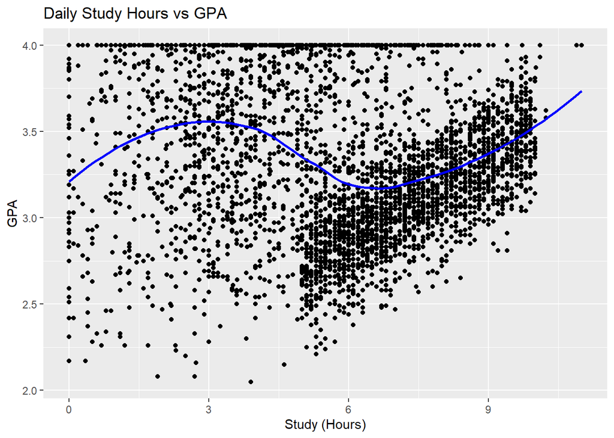

```r
merged_data %>%
  ggplot(aes(x = study, y = gpa)) +
    geom_point() +
    geom_smooth(method = "loess", se = FALSE, color = "blue") +
    labs(title = "Daily Study Hours vs GPA",
         x = "Study (Hours)",
         y = "GPA")
```

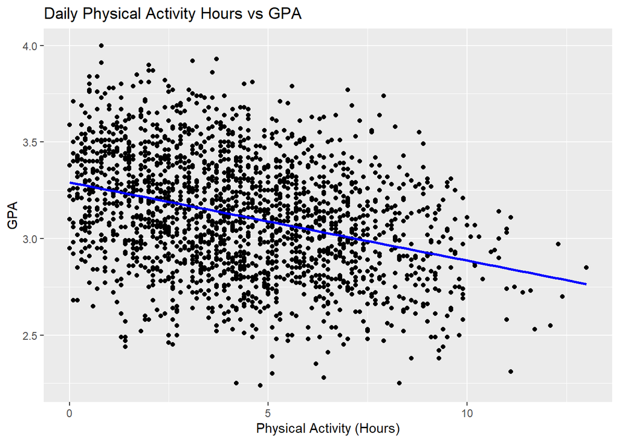

```r
lifestyle_factors %>%
    ggplot(aes(x = Physical_Activity_Hours_Per_Day, y = GPA)) +
    geom_point() +
    geom_smooth(method = "lm", se = FALSE, color = "blue") +
    labs(title = "Daily Physical Activity Hours vs GPA",
         x = "Physical Activity (Hours)",
         y = "GPA")
```

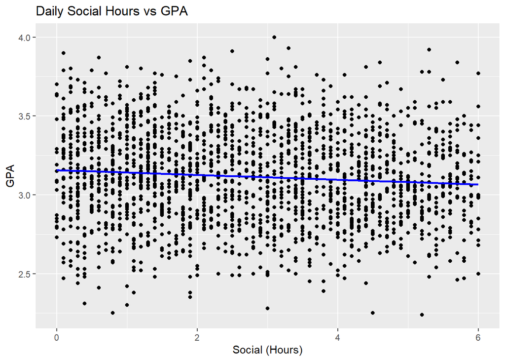

```r
lifestyle_factors %>%
    ggplot(aes(x = Social_Hours_Per_Day, y = GPA)) +
    geom_point() +
    geom_smooth(method = "lm", se = FALSE, color = "blue") +
    labs(title = "Daily Social Hours vs GPA",
         x = "Social (Hours)",
         y = "GPA")
```

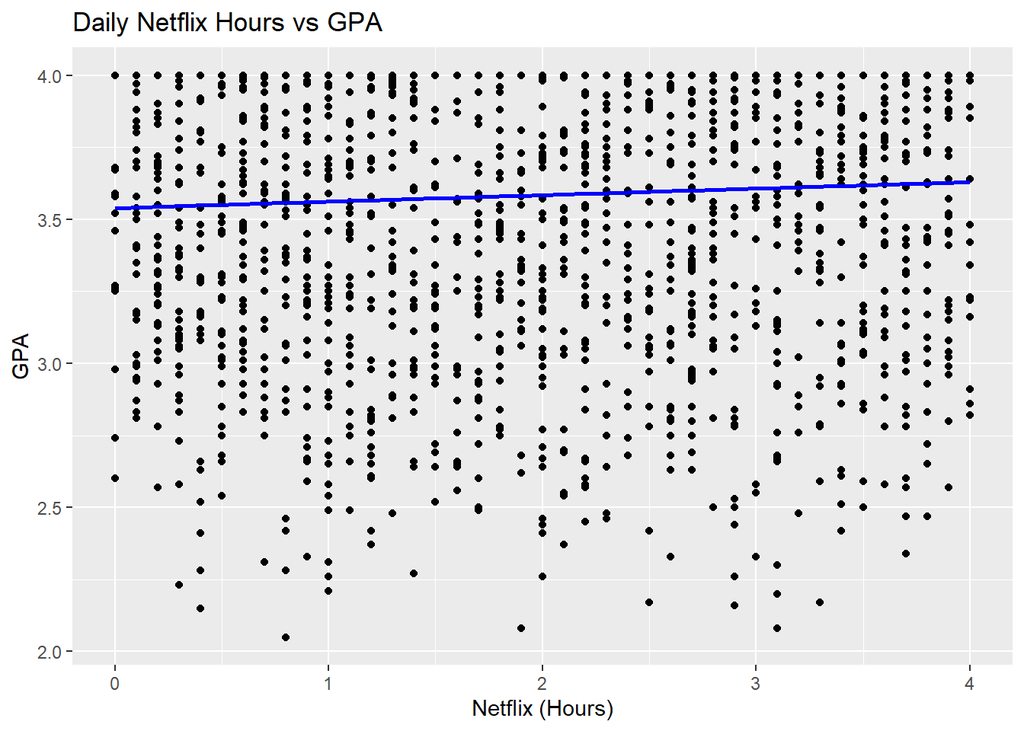

```r
study_habits %>%
    ggplot(aes(x = netflix_hours, y = previous_gpa)) +
    geom_point() +
    geom_smooth(method = "lm", se = FALSE, color = "blue") +
    labs(title = "Daily Netflix Hours vs GPA",
         x = "Netflix (Hours)",
         y = "GPA")
```

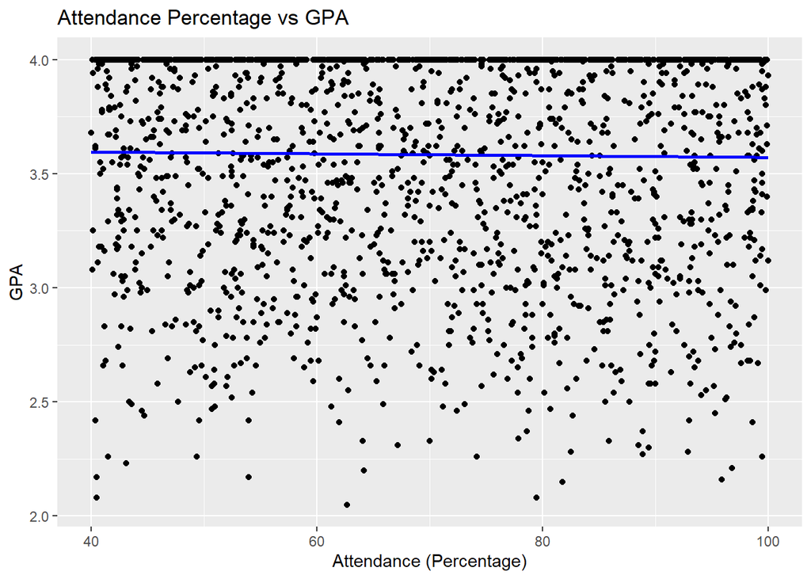

```r
study_habits %>%
    ggplot(aes(x = attendance_percentage, y = previous_gpa)) +
    geom_point() +
    geom_smooth(method = "lm", se = FALSE, color = "blue") +
    labs(title = "Attendance Percentage vs GPA",
         x = "Attendance (Percentage)",
         y = "GPA")
```

### research question 3: stress level research question, how does stress affect gpa across students

```r
library(tidyverse)
```

```r
sm<- read_delim("students_mental_health_survey.csv")
```

```r
sm #just to look at data to see how it looks
```

```
## # A tibble: 7,022 × 20
##      Age Course         Gender  CGPA Stress_Level Depression_Score Anxiety_Score
##    <dbl> <chr>          <chr>  <dbl>        <dbl>            <dbl>         <dbl>
##  1    25 Others         Male    3.56            3                3             2
##  2    24 Engineering    Female  2.44            0                3             0
##  3    19 Business       Female  3.74            4                0             3
##  4    19 Computer Scie… Male    3.65            2                1             0
##  5    18 Business       Male    3.4             3                3             4
##  6    21 Medical        Female  3.35            2                4             3
##  7    18 Law            Male    3.65            2                2             5
##  8    21 Business       Female  3.4             0                3             3
##  9    24 Medical        Male    3.8             3                2             1
## 10    19 Engineering    Female  3.05            2                5             0
## # ℹ 7,012 more rows
## # ℹ 13 more variables: Sleep_Quality <chr>, Physical_Activity <chr>,
## #   Diet_Quality <chr>, Social_Support <chr>, Relationship_Status <chr>,
## #   Substance_Use <chr>, Counseling_Service_Use <chr>, Family_History <chr>,
## #   Chronic_Illness <chr>, Financial_Stress <dbl>,
## #   Extracurricular_Involvement <chr>, Semester_Credit_Load <dbl>,
## #   Residence_Type <chr>
```

```r
sm2<- read_delim("mental_health_dataset.csv")
```

```r
sm2 #just to look at data
```

```
## # A tibble: 500 × 13
##    Student_ID   Age Gender   GPA Stress_Level Anxiety_Score Depression_Score
##         <dbl> <dbl> <chr>  <dbl>        <dbl>         <dbl>            <dbl>
##  1          1    23 Other   2.52            5            20                6
##  2          2    19 Male    2.74            5             3                7
##  3          3    21 Female  3.53            5            11               24
##  4          4    18 Male    2.04            4            15               14
##  5          5    19 Other   2.87            1             2                4
##  6          6    23 Other   2.99            2             3               24
##  7          7    20 Other   3.19            4             7               14
##  8          8    18 Other   2.22            4             1                5
##  9          9    21 Male    3.17            4             7               20
## 10         10    21 Male    2.44            2            12                8
## # ℹ 490 more rows
## # ℹ 6 more variables: Daily_Reflections <chr>, Sleep_Hours <dbl>,
## #   Steps_Per_Day <dbl>, Mood_Description <chr>, Sentiment_Score <dbl>,
## #   Mental_Health_Status <dbl>
```

```r
sm <- sm %>%
  select(CGPA, Stress_Level) %>%
  filter(!is.na(CGPA))


sm2 <- sm2 %>%
  select(GPA, Stress_Level) %>%
  filter(!is.na(GPA))


  sm <- sm %>%
  rename(
    GPA = CGPA
  )

sm2 <- sm2 %>%
  select(GPA, Stress_Level) %>%
  mutate(
    Stress_Level = ((Stress_Level - 1) / 4) * 5,
  )



sm #checking to make sure both look okay
```

```
## # A tibble: 7,010 × 2
##      GPA Stress_Level
##    <dbl>        <dbl>
##  1  3.56            3
##  2  2.44            0
##  3  3.74            4
##  4  3.65            2
##  5  3.4             3
##  6  3.35            2
##  7  3.65            2
##  8  3.4             0
##  9  3.8             3
## 10  3.05            2
## # ℹ 7,000 more rows
```

```r
sm2
```

```
## # A tibble: 500 × 2
##      GPA Stress_Level
##    <dbl>        <dbl>
##  1  2.52         5
##  2  2.74         5
##  3  3.53         5
##  4  2.04         3.75
##  5  2.87         0
##  6  2.99         1.25
##  7  3.19         3.75
##  8  2.22         3.75
##  9  3.17         3.75
## 10  2.44         1.25
## # ℹ 490 more rows
```

```r
combined_sm <- rbind(sm, sm2) #i use rbind to combine the rows, merge would not work for my dataset since it all has different people also no need to add new columns

combined_sm$stress_category <- cut( #had to search up how to categorize
  combined_sm$Stress_Level,
  breaks = c(-1, 2, 4, 6), #seperates the stress levels into categories between -1 to 2, 2 to 4, 4, to 6 aka low, medium, high
  labels = c("Low", "Medium", "High") #these are the categories names and it goes accordingly in order from the previous vector
)

combined_sm # to take a look at the table
```

```
## # A tibble: 7,510 × 3
##      GPA Stress_Level stress_category
##    <dbl>        <dbl> <fct>
##  1  3.56            3 Medium
##  2  2.44            0 Low
##  3  3.74            4 Medium
##  4  3.65            2 Low
##  5  3.4             3 Medium
##  6  3.35            2 Low
##  7  3.65            2 Low
##  8  3.4             0 Low
##  9  3.8             3 Medium
## 10  3.05            2 Low
## # ℹ 7,500 more rows
```

```r
dim(combined_sm) # to make sure it looks correct and shows rows and columns
```

```
## [1] 7510    3
```

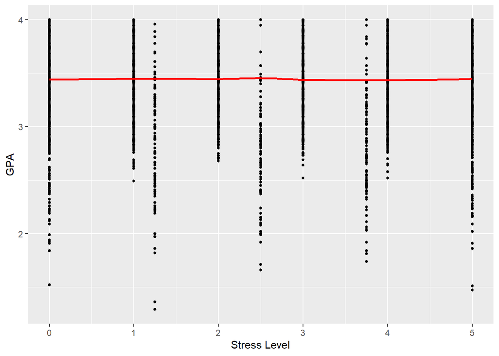

```r
 ggplot(combined_sm, aes(Stress_Level, GPA)) + #plot uses my combined data with stress level and gpa
  geom_point(size = 1) + #makes size of dot to be 1
  geom_smooth(method = "loess", color = "red", se = FALSE) + #this is a loess curve, se = false removes unecessary shading, color is just set to red
   labs(x = "Stress Level",
        y = "GPA" )
```

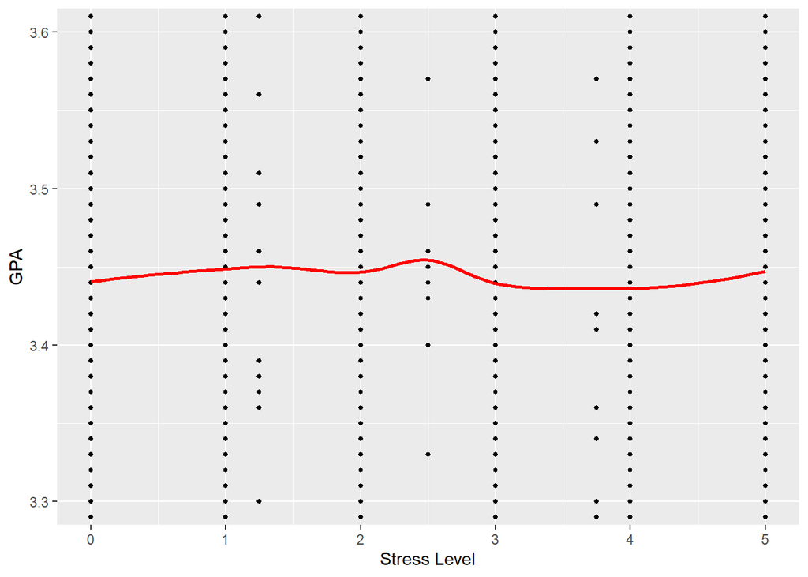

```r
ggplot(combined_sm, aes(Stress_Level, GPA)) +
  geom_point(size = 1) +
  geom_smooth(method = "loess", color = "red", se = FALSE) +
  coord_cartesian(ylim = c(3.3, 3.6)) + #had to search up how to zoom on graph but this function seems to zoom in on the y axis values from 3.3 to 3.6 using ylim.
   labs(x = "Stress Level",
        y = "GPA")
```

### research question 1 How does sleep effect GPA

```r
data1 <- read_delim("students_mental_health_survey.csv")
data1
```

```
## # A tibble: 7,022 × 20
##      Age Course         Gender  CGPA Stress_Level Depression_Score Anxiety_Score
##    <dbl> <chr>          <chr>  <dbl>        <dbl>            <dbl>         <dbl>
##  1    25 Others         Male    3.56            3                3             2
##  2    24 Engineering    Female  2.44            0                3             0
##  3    19 Business       Female  3.74            4                0             3
##  4    19 Computer Scie… Male    3.65            2                1             0
##  5    18 Business       Male    3.4             3                3             4
##  6    21 Medical        Female  3.35            2                4             3
##  7    18 Law            Male    3.65            2                2             5
##  8    21 Business       Female  3.4             0                3             3
##  9    24 Medical        Male    3.8             3                2             1
## 10    19 Engineering    Female  3.05            2                5             0
## # ℹ 7,012 more rows
## # ℹ 13 more variables: Sleep_Quality <chr>, Physical_Activity <chr>,
## #   Diet_Quality <chr>, Social_Support <chr>, Relationship_Status <chr>,
## #   Substance_Use <chr>, Counseling_Service_Use <chr>, Family_History <chr>,
## #   Chronic_Illness <chr>, Financial_Stress <dbl>,
## #   Extracurricular_Involvement <chr>, Semester_Credit_Load <dbl>,
## #   Residence_Type <chr>
```

```r
data2 <- read_delim("student_lifestyle_dataset.csv")
data2
```

```
## # A tibble: 2,000 × 8
##    Student_ID Study_Hours_Per_Day Extracurricular_Hours_Pe…¹ Sleep_Hours_Per_Day
##         <dbl>               <dbl>                      <dbl>               <dbl>
##  1          1                 6.9                        3.8                 8.7
##  2          2                 5.3                        3.5                 8
##  3          3                 5.1                        3.9                 9.2
##  4          4                 6.5                        2.1                 7.2
##  5          5                 8.1                        0.6                 6.5
##  6          6                 6                          2.1                 8
##  7          7                 8                          0.7                 5.3
##  8          8                 8.4                        1.8                 5.6
##  9          9                 5.2                        3.6                 6.3
## 10         10                 7.7                        0.7                 9.8
## # ℹ 1,990 more rows
## # ℹ abbreviated name: ¹Extracurricular_Hours_Per_Day
## # ℹ 4 more variables: Social_Hours_Per_Day <dbl>,
## #   Physical_Activity_Hours_Per_Day <dbl>, GPA <dbl>, Stress_Level <chr>
```

```r
data1_prep <- data1 %>%
  select(-Stress_Level)

data2_prep <- data2 %>%
  select(-Stress_Level)

combined_data <- bind_rows(data1_prep, data2_prep)

combined_data <- combined_data %>%
  mutate(
    GPA = if_else(
      !is.na(GPA),
      GPA,
      CGPA
    )
  ) %>%
  select(-CGPA)

combined_data
```

```
## # A tibble: 9,022 × 25
##      Age Course           Gender Depression_Score Anxiety_Score Sleep_Quality
##    <dbl> <chr>            <chr>             <dbl>         <dbl> <chr>
##  1    25 Others           Male                  3             2 Good
##  2    24 Engineering      Female                3             0 Average
##  3    19 Business         Female                0             3 Good
##  4    19 Computer Science Male                  1             0 Average
##  5    18 Business         Male                  3             4 Good
##  6    21 Medical          Female                4             3 Good
##  7    18 Law              Male                  2             5 Good
##  8    21 Business         Female                3             3 Average
##  9    24 Medical          Male                  2             1 Poor
## 10    19 Engineering      Female                5             0 Average
## # ℹ 9,012 more rows
## # ℹ 19 more variables: Physical_Activity <chr>, Diet_Quality <chr>,
## #   Social_Support <chr>, Relationship_Status <chr>, Substance_Use <chr>,
## #   Counseling_Service_Use <chr>, Family_History <chr>, Chronic_Illness <chr>,
## #   Financial_Stress <dbl>, Extracurricular_Involvement <chr>,
## #   Semester_Credit_Load <dbl>, Residence_Type <chr>, Student_ID <dbl>,
## #   Study_Hours_Per_Day <dbl>, Extracurricular_Hours_Per_Day <dbl>, …
```

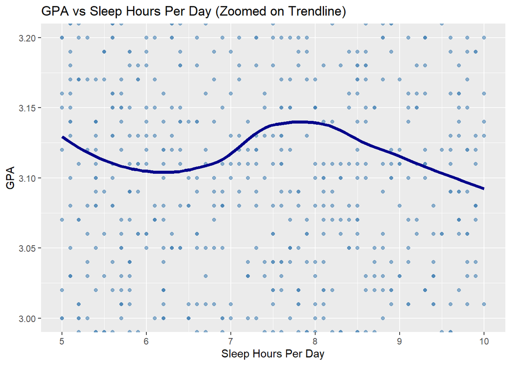

```r
combined_data %>%
  filter(!is.na(GPA) & !is.na(Sleep_Hours_Per_Day)) %>%
  ggplot(aes(x = Sleep_Hours_Per_Day, y = GPA)) +
  geom_point(color = "steelblue", alpha = 0.6) +
  geom_smooth(method = "loess", color = "darkblue", se = FALSE, linewidth = 1.5) +
  coord_cartesian(ylim = c(3.0, 3.2)) +
  labs(
    title = "GPA vs Sleep Hours Per Day (Zoomed on Trendline)",
    x = "Sleep Hours Per Day",
    y = "GPA"
  )
```

### Analysis:

The curve reveals that GPA doesn’t simply increase with more sleep. Instead, there’s an optimal range. The “sweet spot”: GPA appears to peak around 7-8 hours of sleep per day. Students sleeping in this range tend to have GPAs around 3.14. Too little sleep hurts: Students sleeping 5-6 hours show lower average GPAs (around 3.11-3.12). Too much sleep also correlates with lower GPA: Interestingly, students sleeping 9-10 hours also show declining GPAs, dropping back toward 3.10.

citations: used some chatgpt for bind rows.